# Generalised linear models

Michael Hunt

23-01-2024

This exercise is taken from Chapter 7 of Beckerman, Childs and Petchey: Getting Started with R

We study variation of number of offspring of Soay sheep with mother’s body weight. These are count data. They are not normally distributed since they are discrete and bounded by zero - a ewe cannot have a negative number of births. Moreover, the variance of the data set is not constant - the spread of values tends to increase the more offspring a ewe has.

### Load packages

```r
library(tidyverse)
library(ggfortify)
library(here)
library(cowplot)
```

### Load sheep data

```r
filepath <- here("data","soay_sheep_fitness.csv")
soay<-read_csv(filepath)

# check its structure
glimpse(soay)
```

```
## Rows: 50
## Columns: 2
## $ fitness   <dbl> 4, 3, 2, 14, 5, 2, 2, 5, 8, 4, 12, 6, 3, 2, 3, 0, 5, 3, 5, 6…
## $ body.size <dbl> 6.373546, 7.183643, 6.164371, 8.595281, 7.329508, 6.179532, …
```

### Make the first plot to explore the data

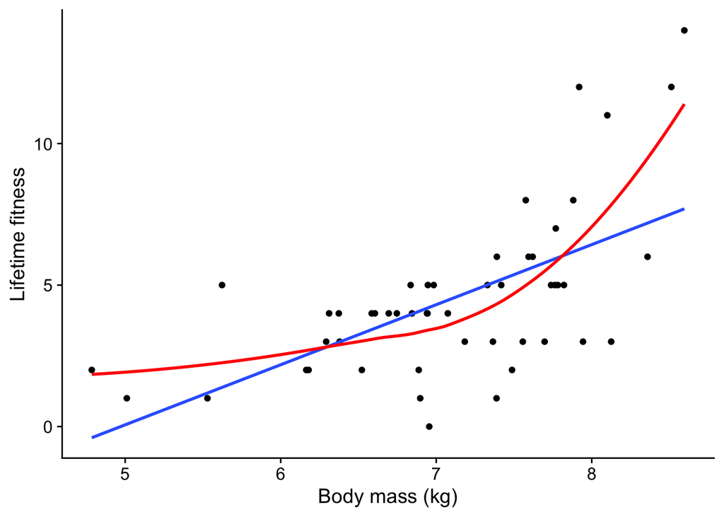

```r
ggplot(soay,aes(x=body.size,y=fitness))+
  geom_point()+
  geom_smooth(method='lm',se=FALSE)+
  geom_smooth(span=1,colour='red',se=FALSE)+
  xlab('Body mass (kg)')+
  ylab('Lifetime fitness')+
  theme_cowplot()
```

### The wrong way to analyse the data - do a linear model

We should have an inkling that this is the wrong way since the variation of offspring with body weight is clearly not linear!

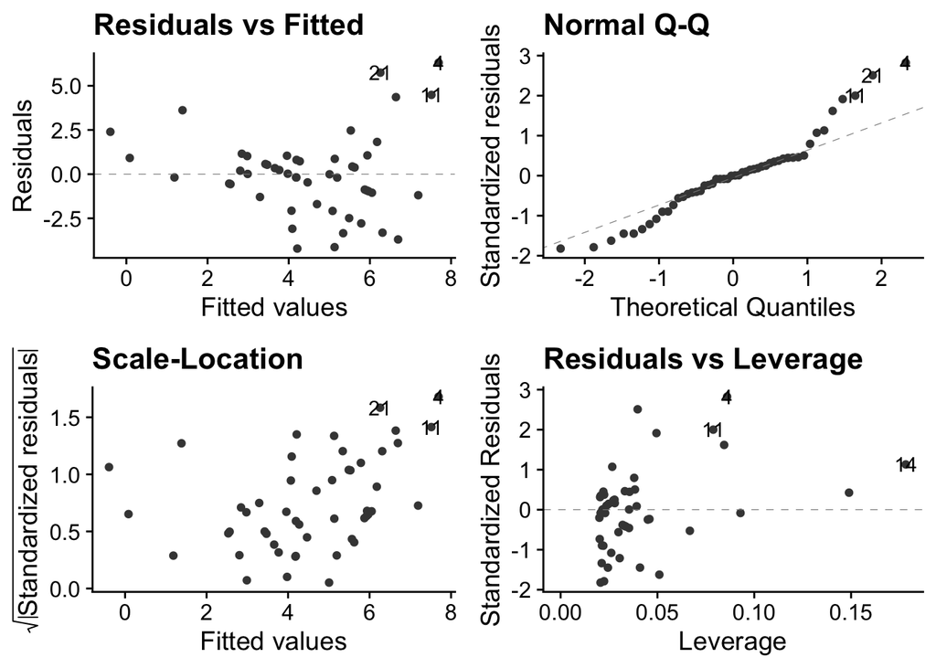

```r
soay.linear<-lm(fitness~body.size,data=soay)
autoplot(soay.linear,smooth.colour=NA) + theme_cowplot()
```

### The right way - using a GLM

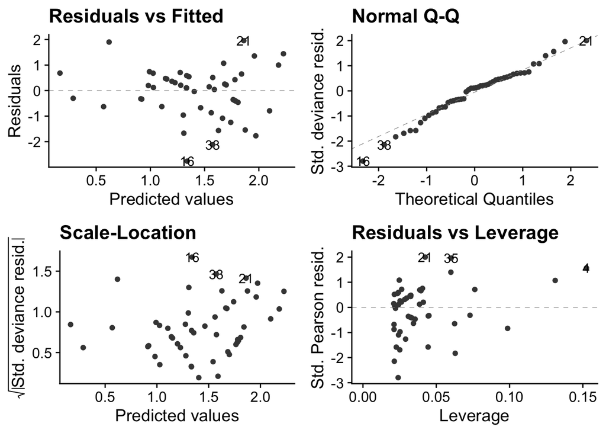

```r
soay.glm<-glm(fitness~body.size,data=soay,family=poisson(link=log))
autoplot(soay.glm,smooth.colour=NA) + theme_cowplot()
```

### Interpret the GLM

```r
# use anova() and summary() to interpret the model
anova(soay.glm) # sequential sums of squares table
```

|  | Df | Deviance | Resid. Df | Resid. Dev |
| --- | --- | --- | --- | --- |
| NULL | NA | NA | 49 | 85.08099 |
| body.size | 1 | 37.0405 | 48 | 48.04049 |

```r
summary(soay.glm) # coefficients table
```

```
##
## Call:
## glm(formula = fitness ~ body.size, family = poisson(link = log),
##     data = soay)
##
## Coefficients:
##             Estimate Std. Error z value Pr(>|z|)
## (Intercept) -2.42203    0.69432  -3.488 0.000486 ***
## body.size    0.54087    0.09316   5.806 6.41e-09 ***
## ---
## Signif. codes:  0 '***' 0.001 '**' 0.01 '*' 0.05 '.' 0.1 ' ' 1
##
## (Dispersion parameter for poisson family taken to be 1)
##
##     Null deviance: 85.081  on 49  degrees of freedom
## Residual deviance: 48.040  on 48  degrees of freedom
## AIC: 210.85
##
## Number of Fisher Scoring iterations: 4
```

### Remake the figure and add fitted line

#### Find min and max of the x data

```r
min.size<-min(soay$body.size)
max.size<-max(soay$body.size)
```

#### Make the new.x values.

We use the ‘body.size’ variable name to name the column just as it is in the orginal data

```r
new.x<-expand.grid(body.size=seq(min.size,max.size,length.out=1000))
```

#### Generate fits and standard errors

```r
new.y<-predict(soay.glm,newdata=new.x,se.fit=TRUE)
new.y<-data.frame(new.y)
head(new.y)
```

|  | fit | se.fit | residual.scale |
| --- | --- | --- | --- |
| 1 | 0.1661991 | 0.2541777 | 1 |
| 2 | 0.1682619 | 0.2538348 | 1 |
| 3 | 0.1703247 | 0.2534919 | 1 |
| 4 | 0.1723874 | 0.2531491 | 1 |
| 5 | 0.1744502 | 0.2528063 | 1 |
| 6 | 0.1765130 | 0.2524635 | 1 |

#### Housekeeping to bring new.x and new.y together

```r
addThese<-data.frame(new.x,new.y)
addThese<-rename(addThese,fitness=fit)
head(addThese)
```

|  | body.size | fitness | se.fit | residual.scale |
| --- | --- | --- | --- | --- |
| 1 | 4.785300 | 0.1661991 | 0.2541777 | 1 |
| 2 | 4.789114 | 0.1682619 | 0.2538348 | 1 |
| 3 | 4.792928 | 0.1703247 | 0.2534919 | 1 |
| 4 | 4.796741 | 0.1723874 | 0.2531491 | 1 |
| 5 | 4.800555 | 0.1744502 | 0.2528063 | 1 |
| 6 | 4.804369 | 0.1765130 | 0.2524635 | 1 |

#### Calculate confidence intervals and include them in addThese

```r
addThese<-mutate(addThese,
                 lwr=fitness-1.96*se.fit,
                 upr=fitness+1.96*se.fit)
```

#### Plot the final figure

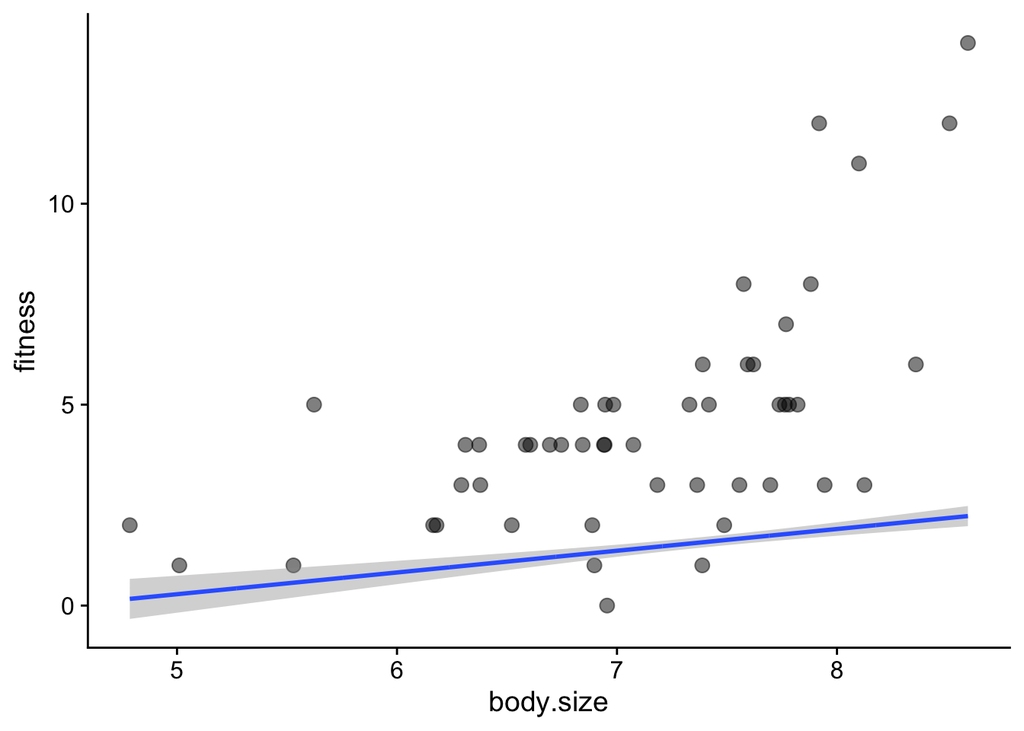

```r
ggplot(soay,aes(x=body.size,y=fitness)) +
  # first show the raw data
  geom_point(size=3,alpha=0.5)+
  # now add the fit and confidence intervals
  # we don't need to specify body.size and fitness as they are inherited from above
  geom_smooth(data=addThese,aes(ymin=lwr,ymax=upr),stat='identity')+
  theme_cowplot()
```

This did not work! We need to account for the link function. For a poisson model, this is the log(). Hence, the predictions are the log of the expected fitness. Here is the fix:

#### Start again with addThese:

```r
addThese<-data.frame(new.x,new.y)
# then:
addThese<-mutate(addThese,
                 fitness=exp(fit),
                 lwr=exp(fit-1.96*se.fit),
                 upr=exp(fit+1.96*se.fit))
head(addThese)
```

|  | body.size | fit | se.fit | residual.scale | fitness | lwr | upr |
| --- | --- | --- | --- | --- | --- | --- | --- |
| 1 | 4.785300 | 0.1661991 | 0.2541777 | 1 | 1.180808 | 0.7174951 | 1.943300 |
| 2 | 4.789114 | 0.1682619 | 0.2538348 | 1 | 1.183246 | 0.7194600 | 1.946004 |
| 3 | 4.792928 | 0.1703247 | 0.2534919 | 1 | 1.185690 | 0.7214303 | 1.948712 |
| 4 | 4.796741 | 0.1723874 | 0.2531491 | 1 | 1.188138 | 0.7234059 | 1.951425 |
| 5 | 4.800555 | 0.1744502 | 0.2528063 | 1 | 1.190591 | 0.7253869 | 1.954141 |
| 6 | 4.804369 | 0.1765130 | 0.2524635 | 1 | 1.193050 | 0.7273732 | 1.956861 |

#### Redo the final plot

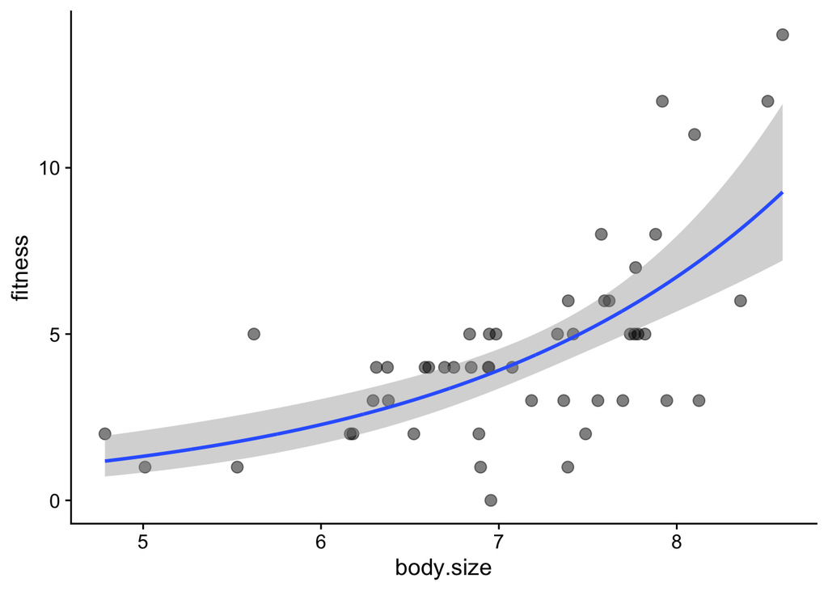

```r
ggplot(soay,aes(x=body.size,y=fitness)) +
  # first show the raw data
  geom_point(size=3,alpha=0.5)+
  # now add the fit and confidence intervals
  # we don't need to specify body.size and fitness as they are inherited from above
  geom_smooth(data = addThese,aes(ymin = lwr,ymax = upr), stat = 'identity')+
  theme_cowplot()
```